José Miguel Castañeda

Carné: 18161

# Lab 4 Regressions

En este laboratorio se trabajará con los datos del archivo insurance.svg extraídos de la página: https://www.kaggle.com/sonujha090/insurance-prediction  
Los datos contienen información de las personas y, en base a esto, cuánto cobra la compañía de seguros para asegurarlos. El objetivo es predecir los cargos del seguro para las nuevas personas en función de la información que obtendremos de ellos.  
Nombres de las columnas: edad, sexo, bmi, niños, fumadores, región, cargos

## Importar Librerías

```python
import pandas as pd
import numpy as np
import matplotlib.pyplot as plt
import seaborn as sns
%matplotlib inline
```

## Exploración de datos

```python
data = pd.read_csv("insurance.csv")
```

**Head del dataset**

```python
data.head()
```

|  | age | sex | bmi | children | smoker | region | charges |
| --- | --- | --- | --- | --- | --- | --- | --- |
| 0 | 19 | 0 | 27.900 | 0 | 1 | 3 | 16884.92400 |
| 1 | 18 | 1 | 33.770 | 1 | 0 | 2 | 1725.55230 |
| 2 | 28 | 1 | 33.000 | 3 | 0 | 2 | 4449.46200 |
| 3 | 33 | 1 | 22.705 | 0 | 0 | 1 | 21984.47061 |
| 4 | 32 | 1 | 28.880 | 0 | 0 | 1 | 3866.85520 |

**Análisis general de la información**

```python
data.info()
```

```
<class 'pandas.core.frame.DataFrame'>
RangeIndex: 348 entries, 0 to 347
Data columns (total 7 columns):
 #   Column    Non-Null Count  Dtype
---  ------    --------------  -----
 0   age       348 non-null    int64
 1   sex       348 non-null    int64
 2   bmi       348 non-null    float64
 3   children  348 non-null    int64
 4   smoker    348 non-null    int64
 5   region    348 non-null    int64
 6   charges   348 non-null    float64
dtypes: float64(2), int64(5)
memory usage: 19.2 KB
```

```python
data.describe()
```

|  | age | sex | bmi | children | smoker | region | charges |
| --- | --- | --- | --- | --- | --- | --- | --- |
| count | 348.000000 | 348.000000 | 348.000000 | 348.000000 | 348.000000 | 348.000000 | 348.000000 |
| mean | 39.591954 | 0.508621 | 30.676552 | 1.091954 | 0.232759 | 1.497126 | 14016.426293 |
| std | 14.417015 | 0.500646 | 5.625850 | 1.192021 | 0.423198 | 1.104089 | 12638.887852 |
| min | 18.000000 | 0.000000 | 15.960000 | 0.000000 | 0.000000 | 0.000000 | 1137.011000 |
| 25% | 27.000000 | 0.000000 | 26.782500 | 0.000000 | 0.000000 | 1.000000 | 4888.466125 |
| 50% | 40.000000 | 1.000000 | 30.300000 | 1.000000 | 0.000000 | 2.000000 | 9719.305250 |
| 75% | 53.000000 | 1.000000 | 34.777500 | 2.000000 | 0.000000 | 2.000000 | 19006.316150 |
| max | 64.000000 | 1.000000 | 49.060000 | 5.000000 | 1.000000 | 3.000000 | 51194.559140 |

**Pairwise agrupado por el sexo**

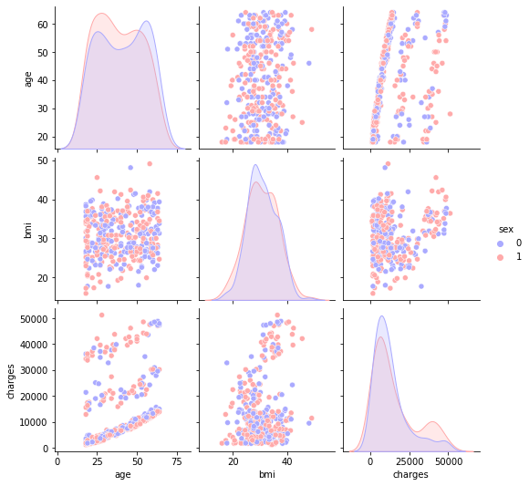

```python
sns.pairplot(data[data.columns[[0,1,2,6]]], hue='sex', palette='bwr')
```

**Pairwise agrupado por cantidad de hijos**

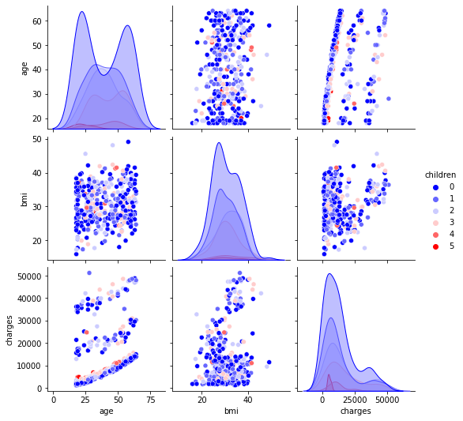

```python
sns.pairplot(data[data.columns[[0,2,3,6]]], hue='children', palette='bwr')
```

**Pairwise agrupado si fuma o no**

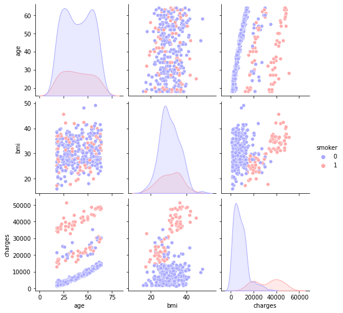

```python
sns.pairplot(data[data.columns[[0,2,4,6]]], hue='smoker', palette='bwr')
```

**Pairwise agrupado por región**

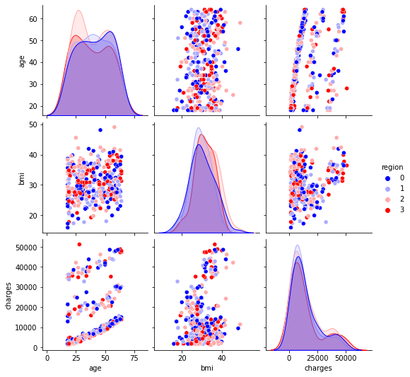

```python
sns.pairplot(data[data.columns[[0,2,5,6]]], hue='region', palette='bwr')
```

## Preparación de los datos

**Se cunentan la cantidad de Null por columna**

```python
data.isnull().sum()
```

```
age         0
sex         0
bmi         0
children    0
smoker      0
region      0
charges     0
dtype: int64
```

No hay valores nulos por lo que la data esta lista para ser analizada.

## Dividir en training y test

**Se divide el dataset en training y test**

```python
from sklearn.model_selection import train_test_split
```

**Para el modelo 2:**

```python
X_1 = data[['bmi']]
y_1 = data['charges']
```

```python
X_train_1, X_test_1, y_train_1, y_test_1 = train_test_split(X_1, y_1, test_size=0.33)
```

**Para el modelo 3:**

```python
X_2 = data[['age', 'sex', 'bmi','children', 'smoker', 'region']]
y_2 = data['charges']
```

```python
X_train_2, X_test_2, y_train_2, y_test_2 = train_test_split(X_2, y_2, test_size=0.33)
```

## Preparación de los datos

**Se aplica normalización y con estandarización al dataset para tener todas las variables independientes en una misma escala**

```python
from sklearn.preprocessing import StandardScaler
```

```python
sc = StandardScaler()
#Para el modelo 2
X_train_1 = sc.fit_transform(X_train_1)
X_test_1 = sc.transform(X_test_1)
#Para el modelo 3
X_train_2 = sc.fit_transform(X_train_2)
X_test_2 = sc.transform(X_test_2)
```

## Modelación Lineal

**Modelo 1 - Sin utilizar ninguna librería**

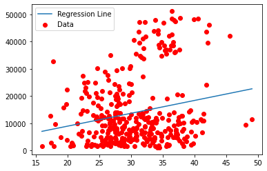

```python
x_model = data['bmi'].to_numpy()
y_model = data['charges'].to_numpy()


x_mean = np.mean(x_model)
y_mean = np.mean(y_model)

n = 0
d = 0
for i in range(len(x_model)):
    n += (x_model[i] - x_mean) * (y_model[i] - y_mean)
    d += (x_model[i] - x_mean) ** 2
m = n / d
c = y_mean - (m * x_mean)

max_x =  + 100
min_x =  - 100

# Calculating line values x and y
x_line = np.linspace(np.min(x_model), np.max(x_model), len(x_model))
y_line = (m * x_line) + c

plt.plot(x_line, y_line, label='Regression Line')
plt.scatter(x_model, y_model, c='red', label='Data')
plt.legend()
plt.show()
```

**Se importa la librería para generar los modelos 2 y 3**

```python
from sklearn.linear_model import LinearRegression
from sklearn.metrics import mean_squared_error, mean_absolute_error, r2_score
import statsmodels.api as sm
```

**Modelo 2**  
Features: bmi

```python
model2 = LinearRegression().fit(X_train_1, y_train_1)
```

```python
y_pred_model2 = model2.predict(X_test_1)
```

Se revisan los p values:

```python
mod = sm.OLS(y_train_1,X_train_1)

fitModel = mod.fit()

fitModel.summary2()
```

| Model: | OLS | Adj. R-squared (uncentered): | 0.008 |
| --- | --- | --- | --- |
| Dependent Variable: | charges | AIC: | 5258.2014 |
| Date: | 2021-04-19 17:24 | BIC: | 5261.6524 |
| No. Observations: | 233 | Log-Likelihood: | -2628.1 |
| Df Model: | 1 | F-statistic: | 2.848 |
| Df Residuals: | 232 | Prob (F-statistic): | 0.0928 |
| R-squared (uncentered): | 0.012 | Scale: | 3.6860e+08 |

|  | Coef. | Std.Err. | t | P>\|t\| | [0.025 | 0.975] |
| --- | --- | --- | --- | --- | --- | --- |
| x1 | 2122.7439 | 1257.7692 | 1.6877 | 0.0928 | -355.3656 | 4600.8535 |

| Omnibus: | 36.155 | Durbin-Watson: | 0.909 |
| --- | --- | --- | --- |
| Prob(Omnibus): | 0.000 | Jarque-Bera (JB): | 49.531 |
| Skew: | 1.128 | Prob(JB): | 0.000 |
| Kurtosis: | 3.125 | Condition No.: | 1 |

**Modelo 3**  
Features: age, sex, bmi, children, smoker, region

```python
model3 = LinearRegression().fit(X_train_2, y_train_2)
```

```python
y_pred_model3 = model3.predict(X_test_2)
```

```python
mod = sm.OLS(y_train_1,X_train_1)

fitModel = mod.fit()

fitModel.summary2()
```

| Model: | OLS | Adj. R-squared (uncentered): | 0.008 |
| --- | --- | --- | --- |
| Dependent Variable: | charges | AIC: | 5258.2014 |
| Date: | 2021-04-19 17:24 | BIC: | 5261.6524 |
| No. Observations: | 233 | Log-Likelihood: | -2628.1 |
| Df Model: | 1 | F-statistic: | 2.848 |
| Df Residuals: | 232 | Prob (F-statistic): | 0.0928 |
| R-squared (uncentered): | 0.012 | Scale: | 3.6860e+08 |

|  | Coef. | Std.Err. | t | P>\|t\| | [0.025 | 0.975] |
| --- | --- | --- | --- | --- | --- | --- |
| x1 | 2122.7439 | 1257.7692 | 1.6877 | 0.0928 | -355.3656 | 4600.8535 |

| Omnibus: | 36.155 | Durbin-Watson: | 0.909 |
| --- | --- | --- | --- |
| Prob(Omnibus): | 0.000 | Jarque-Bera (JB): | 49.531 |
| Skew: | 1.128 | Prob(JB): | 0.000 |
| Kurtosis: | 3.125 | Condition No.: | 1 |

## Evaluación de los modelos

**Modelo 1:**

```python
rmse = 0
for i in range(len(x_model)):
    y_pred_model1 = c + m * x_model[i]
    rmse += (y_model[i] - y_pred_model1) ** 2
rmse = np.sqrt(rmse/n)
print(rmse)
```

```
101.11133200191263
```

Se calcula $R^2$:

```python
total = 0
rest = 0
for i in range(len(x_model)):
    y_pred_model1 = c + m * x_model[i]
    total += (y_model[i] - y_mean) ** 2
    rest += (y_model[i] - y_pred_model1) ** 2
r2 = 1 - (rest/total)
print(r2)
```

```
0.04412123949701052
```

**Modelo 2:**

Se calcula el Mean Squares Error:

```python
mean_squared_error(y_test_1, y_pred_model2, squared=True)
```

```
124939624.84899375
```

Se calcula el Root Mean Squares Error:

```python
mean_squared_error(y_test_1, y_pred_model2, squared=False)
```

```
11177.639502551232
```

Se calcula el Mean Absolute Error:

```python
mean_absolute_error(y_test_1, y_pred_model2)
```

```
8881.578890658742
```

Se calcula $R^2$:

```python
r2_score(y_test_1, y_pred_model2)
```

```
0.08370071861348227
```

**Modelo 3:**

Se calcula el Mean Squares Error:

```python
mean_squared_error(y_test_2, y_pred_model3, squared=True)
```

```
39848575.38912981
```

Se calcula el Root Mean Squares Error:

```python
mean_squared_error(y_test_2, y_pred_model3, squared=False)
```

```
6312.5728026795705
```

Se calcula el Mean Absolute Error:

```python
mean_absolute_error(y_test_2, y_pred_model3)
```

```
4315.2772908440875
```

Se calcula $R^2$:

```python
r2_score(y_test_2, y_pred_model3)
```

```
0.7163723630799588
```

## Regresión Polinomial

```python
from sklearn.preprocessing import PolynomialFeatures
from sklearn.linear_model import Ridge
from sklearn.pipeline import make_pipeline
import matplotlib.pyplot as plt
```

**Modelo 2:**

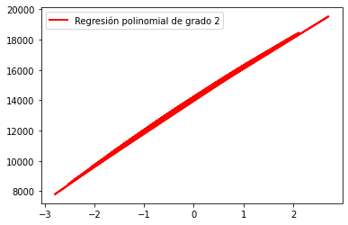

```python
model = make_pipeline(PolynomialFeatures(2), Ridge())
model.fit(X_train_1, y_train_1)
y_plot = model.predict(X_test_1)
plt.plot(X_test_1, y_plot, color='red', linewidth=2, label="Regresión polinomial de grado 2")

plt.legend()

plt.show()
```

[figure not shown]

```python
model = make_pipeline(PolynomialFeatures(2), Ridge())
model.fit(X_train_2, y_train_2)
y_plot = model.predict(X_test_2)
plt.plot(X_test_2, y_plot, color='blue', linewidth=2, label="Regresión polinomial de grado 2")

plt.legend()

plt.show()
```